# Módulo 2. Preparación de imágenes: escala de grises, binarización y contorno

Curso corto: Análisis de contornos de otolitos con R

Luis Cubillos

Noviembre 2026

# Objetivos del módulo

1. Entender una imagen digital como una **matriz** de valores.
2. Leer imágenes en R con el paquete `pixmap` y convertirlas a **escala de grises**.
3. Ajustar contraste y **binarizar** con un umbral (manual y automático).
4. **Extraer el contorno** del otolito con la función `Conte()` de Claude (2008).
5. Calibrar la **escala** (píxeles → mm).

```r
library(pixmap)     # lectura de imágenes PNM (.ppm, .pgm)
# Funciones de Claude (2008) en la carpeta R/ del curso
for (f in list.files("R", full.names = TRUE)) source(f)
```

# Imágenes digitales

# Una imagen es una matriz

Claude (2008, secc. 2.1.1):

- **Binaria** (blanco y negro): cada píxel vale 0 o 1.
- **Escala de grises**: cada píxel toma un valor entre 0 (negro) y 1 (blanco), con $2^n$ niveles (8 bits = 256 niveles).
- **Color (RGB)**: tres valores por píxel (rojo, verde, azul) → un **arreglo** de 3 capas, o tres matrices.

Fila y columna de la matriz = posición del píxel; el valor de la celda = nivel de gris. Toda la manipulación de imágenes se reduce a **operaciones con matrices**.

```r
m <- matrix(c(0, 0, 1, 1,
              0, 1, 1, 0,
              1, 1, 0, 0), 3, 4, byrow = TRUE)
m
```

```
#>      [,1] [,2] [,3] [,4]
#> [1,]    0    0    1    1
#> [2,]    0    1    1    0
#> [3,]    1    1    0    0
```

# Formatos y conversión

- `pixmap` lee el formato **PNM**: `.ppm` (color), `.pgm` (grises), `.pbm` (binario).
- Las fotos de lupa suelen venir en `.jpg` o `.tif`: se convierten con GIMP, ImageMagick (`magick foto.jpg foto.ppm`) o desde R con el paquete `magick`:

```r
library(magick)
im <- image_read("Fotos/oto_001.jpg")
im <- image_convert(im, colorspace = "gray")   # opcional: a grises
im <- image_scale(im, "25%")                    # opcional: reducir resolución
image_write(im, "Fotos/oto_001.pgm", format = "pgm")
```

La imagen del curso (`datos/otolito_scom.pgm`) es un otolito de **sardina común** fotografiado con luz reflejada sobre fondo negro. El original (3648 × 2736 píxeles, 30 MB) se redujo tomando 1 de cada 4 píxeles para acelerar los cálculos.

# Leer la imagen con `pixmap`

```r
img <- read.pnm("datos/otolito_scom.pgm")
class(img)
```

```
#> [1] "pixmapGrey"
#> attr(,"package")
#> [1] "pixmap"
```

```r
G <- img@grey            # matriz de grises: filas x columnas
dim(G)
```

```
#> [1] 684 912
```

```r
range(G)
```

```
#> [1] 0.0000000 0.9647059
```

```r
G[300:303, 400:404]      # una pequeña ventana de la matriz
```

```
#>           [,1]      [,2]      [,3]      [,4]      [,5]
#> [1,] 0.6862745 0.6901961 0.6862745 0.6823529 0.6862745
#> [2,] 0.6980392 0.6745098 0.6980392 0.6901961 0.6901961
#> [3,] 0.6862745 0.6941176 0.6901961 0.6784314 0.7058824
#> [4,] 0.6862745 0.6666667 0.6941176 0.7019608 0.7137255
```

Si la imagen es a color (`.ppm`), primero se convierte a grises:

```r
img <- read.pnm("foto.ppm")          # objeto pixmapRGB (capas @red, @green, @blue)
img <- as(img, "pixmapGrey")         # promedio ponderado de los tres canales
```

# Mostrar la imagen

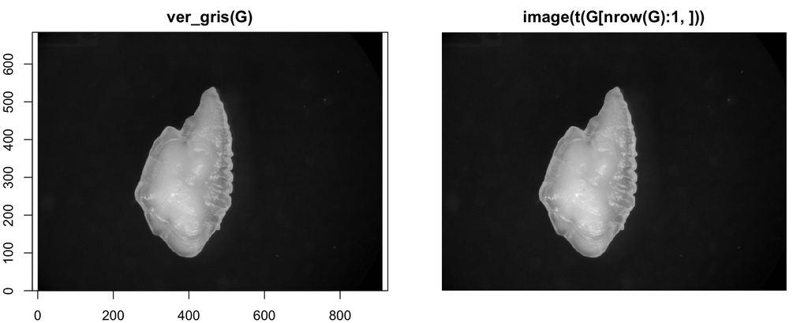

```r
par(mfrow = c(1, 2), mar = c(2, 2, 2, 1))
ver_gris(G, main = "ver_gris(G)", ejes = TRUE)
image(t(G[nrow(G):1, ]), col = gray(0:255 / 255), asp = nrow(G) / ncol(G),
      axes = FALSE, main = "image(t(G[nrow(G):1, ]))")
```

**Ojo con la orientación**: en la matriz la fila 1 es la parte **superior** de la imagen, pero en un gráfico *y* crece hacia arriba. `image(G)` sin invertir dibuja la imagen girada (Claude 2008, p. 48). `ver_gris()` (función del curso) usa `x = columna` e `y = nº filas − fila`, igual que `Conte()`.

# Profundidad de gris

Claude (2008, fig. 2.6): la misma imagen con 256, 4 y 2 niveles de gris.

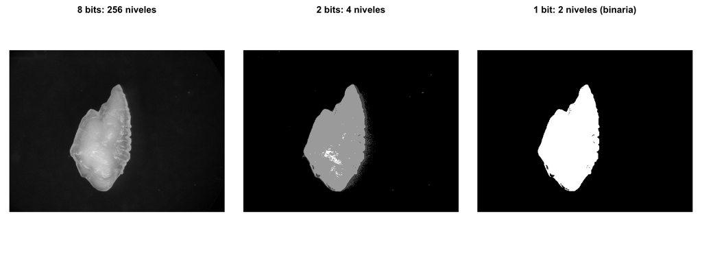

```r
par(mfrow = c(1, 3), mar = c(1, 1, 2, 1))
ver_gris(G,                     main = "8 bits: 256 niveles")
ver_gris(round(G * 3) / 3,      main = "2 bits: 4 niveles")
ver_gris(round(G),              main = "1 bit: 2 niveles (binaria)")
```

Con 1 bit ya se separa el otolito del fondo: esa es la idea de la **binarización**.

# Ajustar contraste, invertir, aclarar

Claude (2008, pp. 45–46): operaciones aritméticas sobre la matriz.

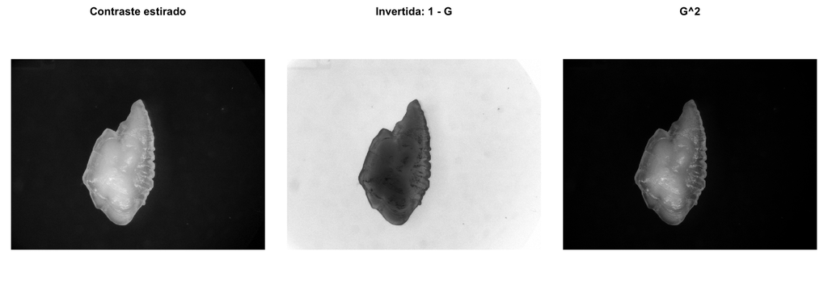

```r
G_con <- (G - min(G)) / diff(range(G))   # estira el rango a [0, 1]
G_inv <- 1 - G                           # invierte: el otolito queda oscuro
G_osc <- G^2                             # potencia > 1 oscurece; < 1 aclara
par(mfrow = c(1, 3), mar = c(1, 1, 2, 1))
ver_gris(G_con, main = "Contraste estirado")
ver_gris(G_inv, main = "Invertida: 1 - G")
ver_gris(G_osc, main = "G^2")
```

Mejorar el contraste **antes** de binarizar facilita separar el objeto del fondo.

# Histograma de niveles de gris

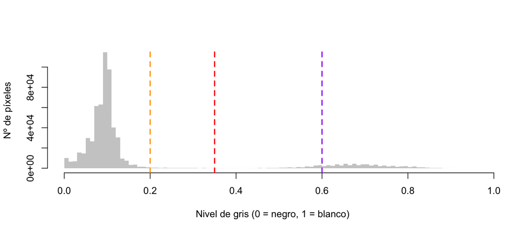

```r
hist(G, breaks = 100, col = "grey80", border = NA, main = "",
     xlab = "Nivel de gris (0 = negro, 1 = blanco)", ylab = "Nº de píxeles")
abline(v = c(0.2, 0.35, 0.6), col = c("orange", "red", "purple"), lwd = 2, lty = 2)
```

- Pico grande en valores bajos: el **fondo** negro.
- Cola de valores altos: el **otolito** (claro).
- El **umbral** debe caer en el valle entre ambos.

# Binarización

# Umbral manual

Cada píxel pasa a **objeto (0, negro)** o **fondo (1, blanco)** según el umbral. `Conte()` espera el objeto en negro.

```r
binarizar <- function(G, umbral) {
  B <- ifelse(G > umbral, 0, 1)                      # otolito (claro) -> 0
  B[c(1, nrow(B)), ] <- 1; B[, c(1, ncol(B))] <- 1   # marco blanco de seguridad
  B
}
```

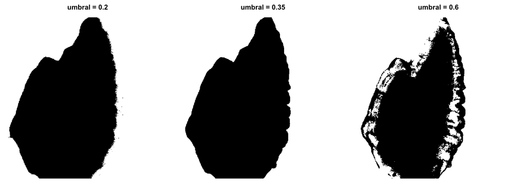

```r
par(mfrow = c(1, 3), mar = c(1, 1, 2, 1))
for (u in c(0.2, 0.35, 0.6)) ver_gris(binarizar(G, u)[150:550, 250:650], main = paste("umbral =", u))
```

# ¿Qué umbral elegir?

- **Muy bajo** (0.2): incluye sombras y reflejos del fondo; el borde se “engorda”.
- **Muy alto** (0.6): se pierden las zonas translúcidas del borde y aparecen **huecos** dentro del otolito.
- **Intermedio** (0.35): borde limpio.

El umbral es subjetivo: se fija **una vez** y se aplica a **todas** las imágenes tomadas con la misma iluminación y aumento.

```r
B <- binarizar(G, 0.35)
sum(B == 0)        # superficie del otolito en píxeles (Claude 2008, p. 44)
```

```
#> [1] 75968
```

# Umbral automático (método de Otsu)

*Complemento* (no está en Claude 2008): Otsu (1979) elige el umbral que **maximiza la varianza entre** las dos clases (fondo y objeto).

```r
umbral_otsu <- function(G, nb = 256) {
  h  <- hist(G, breaks = seq(0, 1, length = nb + 1), plot = FALSE)
  p  <- h$counts / sum(h$counts)          # probabilidad de cada nivel
  w  <- cumsum(p)                         # peso de la clase "fondo"
  mu <- cumsum(p * h$mids)                # media acumulada
  sb <- (mu[nb] * w - mu)^2 / (w * (1 - w))   # varianza entre clases
  h$mids[which.max(sb)]
}
umbral_otsu(G)
```

```
#> [1] 0.3808594
```

Útil como punto de partida o para procesar lotes; igual hay que **revisar** el resultado visualmente.

# Extracción del contorno

# La función `Conte()` (Claude 2008, función 2.1)

Algoritmo de **seguimiento de bordes** con 8 vecinos:

1. Parte de un punto **dentro** del objeto y avanza hacia la **izquierda** hasta encontrar un cambio de valor: ese es el primer píxel del contorno.
2. Examina los vecinos del píxel actual girando en **sentido horario** hasta encontrar el siguiente píxel del borde.
3. Repite hasta volver al punto de partida.

```r
Conte(x, imagematrix)
# x:           c(x, y) de un punto dentro del objeto, en su parte izquierda
# imagematrix: matriz de la imagen (binarizada)
# Devuelve:    list(X, Y) con las coordenadas de todos los píxeles del borde
```

El resultado tiene un punto por píxel: la **abscisa curvilínea** es de 1 píxel.

# Punto inicial y coordenadas

- En el libro, el punto inicial se marca con el ratón: `locator(1)`.
- Para que sea **reproducible**, aquí se usa la mediana de los píxeles del objeto.
- Coordenadas del gráfico: **x = columna**, **y = nº de filas − fila**.

```r
pix <- which(B == 0, arr.ind = TRUE)                  # (fila, columna) del otolito
inicio <- c(round(median(pix[, "col"])),              # x
            nrow(B) - round(median(pix[, "row"])))    # y
cont <- Conte(inicio, B)
str(cont)
```

```
#> List of 2
#>  $ X: num [1:1051] 272 271 271 270 269 269 268 267 267 266 ...
#>  $ Y: num [1:1051] 292 291 290 289 288 287 286 285 284 283 ...
```

```r
length(cont$X)                                        # nº de píxeles del borde
```

```
#> [1] 1051
```

# Contorno extraído

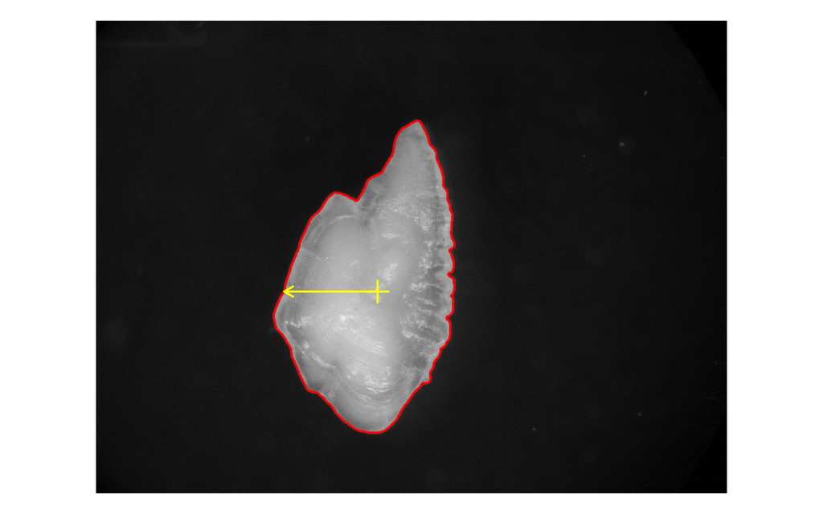

```r
par(mar = c(1, 1, 1, 1))
ver_gris(G)
lines(cont$X, cont$Y, col = "red", lwd = 2)
points(inicio[1], inicio[2], pch = 3, col = "yellow", cex = 2, lwd = 2)
arrows(inicio[1], cont$Y[1], cont$X[1], cont$Y[1], length = 0.1, col = "yellow", lwd = 2)
```

Cruz: punto inicial. Flecha: desplazamiento hacia la izquierda hasta el borde.

# Cuidado con los huecos

Con umbral 0.6 el otolito tiene huecos; si el desplazamiento hacia la izquierda encuentra un **hueco** antes que el borde externo, `Conte()` recorre el hueco:

```r
B6 <- binarizar(G, 0.6)
p6 <- which(B6 == 0, arr.ind = TRUE)
i6 <- c(round(median(p6[, "col"])), nrow(B6) - round(median(p6[, "row"])))
c6 <- Conte(i6, B6)
length(c6$X)            # ¡muy pocos píxeles!
```

```
#> [1] 23
```

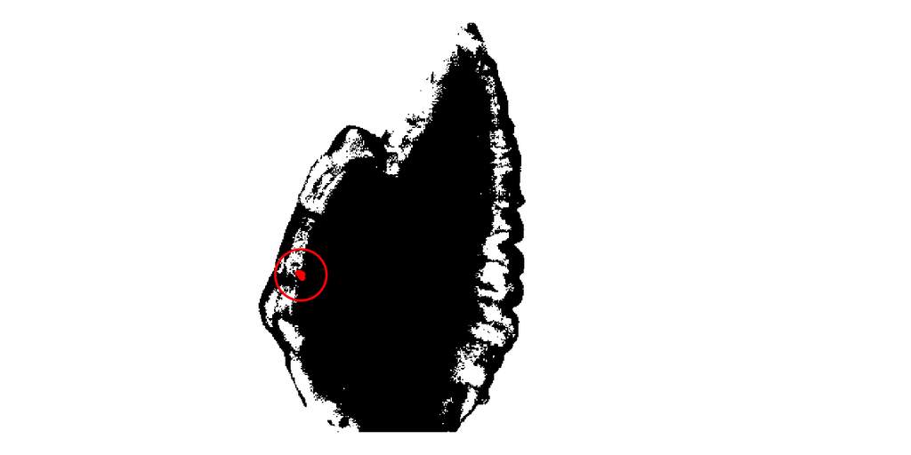

```r
par(mar = c(1, 1, 1, 1))
ver_gris(B6[150:550, 250:650])
lines(c6$X - 249, c6$Y - (nrow(G) - 550), col = "red", lwd = 3)
points(mean(c6$X) - 249, mean(c6$Y) - (nrow(G) - 550), cex = 6, col = "red", lwd = 2)  # el "contorno"
```

Soluciones: bajar el umbral, mover el punto inicial o **rellenar** los huecos. Con algunos puntos iniciales mal ubicados `Conte()` puede incluso **no terminar** nunca: si tarda más de unos segundos, interrumpa (Esc) y revise la binarización.

# Alternativa interactiva (como en el libro)

```r
ver_gris(B)
ini  <- locator(1)                       # clic DENTRO del otolito, en su lado izquierdo
cont <- Conte(c(round(ini$x), round(ini$y)), B)
lines(cont$X, cont$Y, col = "red", lwd = 2)
```

`locator()` lee la posición del cursor cada vez que se presiona el botón izquierdo del ratón (Claude 2008, secc. 2.2.6). Solo funciona en una sesión interactiva (RStudio o R), no al tejer el documento.

# Escala

# De píxeles a milímetros

Fotografiar el otolito **junto a una escala** (regla o micrómetro). Claude (2008, p. 26):

$$\text{coordenadas reales} =
\frac{\text{coordenadas en la imagen} \times \text{tamaño real de la
escala}}{\text{tamaño de la escala en la imagen}}$$

```r
ver_gris(G)
a <- locator(2, type = "o", pch = 8, lwd = 2, col = "green")  # extremos de 1 mm
escala_px <- sqrt(diff(a$x)^2 + diff(a$y)^2)                   # píxeles por mm
X_mm <- cont$X / escala_px
Y_mm <- cont$Y / escala_px
```

Si la imagen se redujo (1 de cada 4 píxeles), la escala debe medirse **en la imagen reducida** o dividirse por 4. Cuidado también con píxeles no cuadrados (relaciones 4:3, 16:9; Claude 2008, p. 43).

# Resumen y ejercicio

imagen → `read.pnm()` → grises (`@grey`) → histograma → `binarizar()` → `Conte()` → contorno en píxeles

**Ejercicio**

1. Binarice la imagen con los umbrales 0.25, 0.30, 0.40 y 0.45. ¿Cambia el número de píxeles del contorno? ¿Y el área?
2. Calcule el umbral de Otsu sobre la imagen invertida (`1 - G`). ¿Qué ocurre?
3. Desplace el punto inicial 100 píxeles a la derecha. ¿Obtiene el mismo contorno?
4. Guarde el contorno en un objeto `cont` para el módulo 3:

```r
saveRDS(cont, "datos/contorno_pixeles.rds")
```

Otsu, N. (1979). A threshold selection method from gray-level histograms. *IEEE Trans. Syst. Man Cybern.* 9: 62–66.